# 医学研究のためのRによるデータ分析入門（オーム社）

加葉田大志朗・新谷歩

2023-06-01

# 第1章 | RとRSTUDIOの準備

## 1.2. Rstudioの基本的な操作方法

四則演算

```r
# 足し算
5 + 5
```

```
[1] 10
```

```r
# 引き算
5 - 5
```

```
[1] 0
```

```r
# 掛け算
5 * 5
```

```
[1] 25
```

```r
# 割り算
5 / 5
```

```
[1] 1
```

```r
# 累乗
5 ** 2
```

```
[1] 25
```

```r
5 ^ 2
```

```
[1] 25
```

```r
5 ^ (1/2)
```

```
[1] 2.236068
```

```r
# 四則演算のルール
5 + 2*5
```

```
[1] 15
```

```r
(5+5)/5
```

```
[1] 2
```

## 1.3. Rにおけるデータ分析の基本動作

### 1.3.1. 演算結果をオブジェクトに代入する

```r
ten <- 5 + 5
ten
```

```
[1] 10
```

```r
ten + ten
```

```
[1] 20
```

### 1.3.2. 関数で演算を行う

```r
total <- 60 + 65 + 70 + 75 + 80
total
```

```
[1] 350
```

```r
total/5
```

```
[1] 70
```

```r
total <- sum(60, 65, 70, 75, 80)
total
```

```
[1] 350
```

```r
total/5
```

```
[1] 70
```

# 第2章 | データの前処理

## 2.1. データファイルの読みこみ

### 2.1.3. CSVファイルの読みこみ（基本編）

```r
df <- read.csv(file = "original.csv")
head(df)
```

```
  id sex_m1 age ps depth_mm treat_y1 event_y1  date_strt  date_stop
1  1      1  62  0       16        0        0 2000-10-15 2014-07-01
2  2      1  47  1       10        0        1 2000-10-21 2006-07-28
3  3      0  33  0       14        0        0 2000-10-27 2002-04-08
4  4      1  61  0       18        0        0 2000-10-27 2011-01-24
5  5      0  66  0       18        1        0 2000-10-31 2013-04-25
6  6      1  57  0       15        0        1 2000-10-31 2001-09-13
```

```r
#View(x = df)
```

### 2.1.4. CSVファイルの読みこみ（応用編）

```r
df2 <- read.csv(file = "C:/Users/kabajiro/Desktop/Rlecture/original.csv")
head(df2)
```

```
  id sex_m1 age ps depth_mm treat_y1 event_y1  date_strt  date_stop
1  1      1  62  0       16        0        0 2000-10-15 2014-07-01
2  2      1  47  1       10        0        1 2000-10-21 2006-07-28
3  3      0  33  0       14        0        0 2000-10-27 2002-04-08
4  4      1  61  0       18        0        0 2000-10-27 2011-01-24
5  5      0  66  0       18        1        0 2000-10-31 2013-04-25
6  6      1  57  0       15        0        1 2000-10-31 2001-09-13
```

```r
getwd()
```

```
[1] "C:/Users/kabajiro/Dropbox/01_主導研究/001_書籍/02_オーム社_Rプログラミング/R_オーム社_20220829"
```

### 2.1.5. Excelファイルの読みこみと外部パッケージ

```r
# パッケージ
#install.packages(pkgs = "openxlsx")
library(package = openxlsx)

df3 <- read.xlsx(xlsxFile = "original.xlsx")
head(df3)
```

```
  id sex_m1 age ps depth_mm treat_y1 event_y1 date_strt date_stop
1  1      1  62  0       16        0        0     36814     41821
2  2      1  47  1       10        0        1     36820     38926
3  3      0  33  0       14        0        0     36826     37354
4  4      1  61  0       18        0        0     36826     40567
5  5      0  66  0       18        1        0     36830     41389
6  6      1  57  0       15        0        1     36830     37147
```

シートを指定する場合

```r
# read.xlsx(xlsxFile = "original.xlsx", sheet = 1)
# read.xlsx(xlsxFile = "original.xlsx", sheet = "Sheet 1")
```

## 2.2. データフレームの取扱い

### 2.2.1. データフレームの構造

データフレームの内容の確認

```r
nrow(x = df)
```

```
[1] 1000
```

```r
ncol(x = df)
```

```
[1] 9
```

```r
dim(x = df)
```

```
[1] 1000    9
```

```r
names(x = df)
```

```
[1] "id"        "sex_m1"    "age"       "ps"        "depth_mm"  "treat_y1"
[7] "event_y1"  "date_strt" "date_stop"
```

```r
colnames(x = df)
```

```
[1] "id"        "sex_m1"    "age"       "ps"        "depth_mm"  "treat_y1"
[7] "event_y1"  "date_strt" "date_stop"
```

```r
summary(object = df)
```

```
       id             sex_m1           age              ps
 Min.   :   1.0   Min.   :0.000   Min.   : 7.00   Min.   :0.0000
 1st Qu.: 250.8   1st Qu.:0.000   1st Qu.:44.00   1st Qu.:0.0000
 Median : 500.5   Median :1.000   Median :55.00   Median :0.0000
 Mean   : 500.5   Mean   :0.595   Mean   :53.22   Mean   :0.3105
 3rd Qu.: 750.2   3rd Qu.:1.000   3rd Qu.:65.00   3rd Qu.:1.0000
 Max.   :1000.0   Max.   :1.000   Max.   :89.00   Max.   :3.0000
                                                  NA's   :53
    depth_mm        treat_y1      event_y1      date_strt
 Min.   : 2.00   Min.   :0.0   Min.   :0.000   Length:1000
 1st Qu.:11.00   1st Qu.:0.0   1st Qu.:0.000   Class :character
 Median :14.00   Median :0.0   Median :0.000   Mode  :character
 Mean   :14.29   Mean   :0.1   Mean   :0.369
 3rd Qu.:17.00   3rd Qu.:0.0   3rd Qu.:1.000
 Max.   :40.00   Max.   :1.0   Max.   :1.000
 NA's   :23
  date_stop
 Length:1000
 Class :character
 Mode  :character
```

```r
# install.packages("rms")
library(rms)
describe(x = df)
```

```
df

 9  Variables      1000  Observations
--------------------------------------------------------------------------------
id
       n  missing distinct     Info     Mean      Gmd      .05      .10
    1000        0     1000        1    500.5    333.7    50.95   100.90
     .25      .50      .75      .90      .95
  250.75   500.50   750.25   900.10   950.05

lowest :    1    2    3    4    5, highest:  996  997  998  999 1000
--------------------------------------------------------------------------------
sex_m1
       n  missing distinct     Info      Sum     Mean      Gmd
    1000        0        2    0.723      595    0.595   0.4824

--------------------------------------------------------------------------------
age
       n  missing distinct     Info     Mean      Gmd      .05      .10
    1000        0       75        1    53.22    16.98    26.00    31.00
     .25      .50      .75      .90      .95
   44.00    55.00    65.00    71.00    74.05

lowest :  7 10 11 13 14, highest: 83 84 85 86 89
--------------------------------------------------------------------------------
ps
       n  missing distinct     Info     Mean      Gmd
     947       53        4    0.587   0.3105   0.4808

Value       0.00  0.99  1.98  3.00
Frequency    699   209    32     7
Proportion 0.738 0.221 0.034 0.007

For the frequency table, variable is rounded to the nearest 0.03
--------------------------------------------------------------------------------
depth_mm
       n  missing distinct     Info     Mean      Gmd      .05      .10
     977       23       34    0.995    14.29    5.139        8        9
     .25      .50      .75      .90      .95
      11       14       17       20       22
```

[output cut: 12 more lines]

```
--------------------------------------------------------------------------------
date_strt
       n  missing distinct
    1000        0      888

lowest : 2000-02-15 2000-03-03 2000-03-13 2000-04-24 2000-05-03
highest: 2014-01-01 2014-01-02 2014-01-11 2014-02-05 2014-04-05
--------------------------------------------------------------------------------
date_stop
       n  missing distinct
    1000        0      854

lowest : 2001-06-24 2001-07-29 2001-08-25 2001-09-13 2001-10-15
highest: 2017-02-15 2017-02-24 2017-03-24 2017-04-18 2017-07-22
--------------------------------------------------------------------------------
```

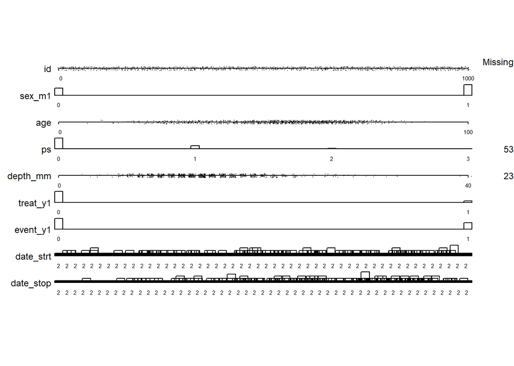

```r
datadensity(object = df)
```

データフレームから任意の行・列を抽出する

```r
df30 <- df[1:30,]
df30
```

```
   id sex_m1 age ps depth_mm treat_y1 event_y1  date_strt  date_stop
1   1      1  62  0       16        0        0 2000-10-15 2014-07-01
2   2      1  47  1       10        0        1 2000-10-21 2006-07-28
3   3      0  33  0       14        0        0 2000-10-27 2002-04-08
4   4      1  61  0       18        0        0 2000-10-27 2011-01-24
5   5      0  66  0       18        1        0 2000-10-31 2013-04-25
6   6      1  57  0       15        0        1 2000-10-31 2001-09-13
7   7      1  37  0       12        0        1 2000-11-02 2003-06-27
8   8      1  54  0       15        0        0 2000-11-20 2005-08-23
9   9      1  39  0        9        0        0 2000-11-30 2005-06-03
10 10      0  43  0        9        0        1 2000-11-07 2016-05-21
11 11      1  32  0       12        0        1 2000-12-13 2011-10-30
12 12      1  64  0       18        0        1 2000-12-18 2002-10-14
13 13      1  19  0       15        0        0 2000-12-21 2001-11-23
14 14      0  29  0       21        1        1 2000-02-15 2011-09-09
```

[output cut: 16 more lines]

```r
df30[,"age"]
```

```
 [1] 62 47 33 61 66 57 37 54 39 43 32 64 19 29 57 66 54 67 61 69 47 11 51 49 54
[26] 66 61 37 72 66
```

```r
df30[,c("age","sex_m1")]
```

```
   age sex_m1
1   62      1
2   47      1
3   33      0
4   61      1
5   66      0
6   57      1
7   37      1
8   54      1
9   39      1
10  43      0
11  32      1
12  64      1
13  19      1
14  29      0
```

[output cut: 16 more lines]

```r
df30$age
```

```
 [1] 62 47 33 61 66 57 37 54 39 43 32 64 19 29 57 66 54 67 61 69 47 11 51 49 54
[26] 66 61 37 72 66
```

### 2.2.2. データの内容を編集する

```r
sex = df30[,"sex_m1"]
sex
```

```
 [1] 1 1 0 1 0 1 1 1 1 0 1 1 1 0 1 1 1 0 1 1 1 0 0 0 1 0 0 1 0 1
```

```r
sex == 1
```

```
 [1]  TRUE  TRUE FALSE  TRUE FALSE  TRUE  TRUE  TRUE  TRUE FALSE  TRUE  TRUE
[13]  TRUE FALSE  TRUE  TRUE  TRUE FALSE  TRUE  TRUE  TRUE FALSE FALSE FALSE
[25]  TRUE FALSE FALSE  TRUE FALSE  TRUE
```

```r
sex_lab = ifelse(sex==1, "Male", "Female")
sex_lab
```

```
 [1] "Male"   "Male"   "Female" "Male"   "Female" "Male"   "Male"   "Male"
 [9] "Male"   "Female" "Male"   "Male"   "Male"   "Female" "Male"   "Male"
[17] "Male"   "Female" "Male"   "Male"   "Male"   "Female" "Female" "Female"
[25] "Male"   "Female" "Female" "Male"   "Female" "Male"
```

```r
ps = df30$ps
ps
```

```
 [1]  0  1  0  0  0  0  0  0  0  0  0  0  0  0  0  0  1  0  2  1  0  0  0  0  1
[26]  0  0 NA  0  0
```

```r
ps_lab = ifelse(ps==0, "Grade0",
                ifelse(ps==1, "Grade1",
                       ifelse(ps==2, "Grade2", "Grade3")))

ps_lab
```

```
 [1] "Grade0" "Grade1" "Grade0" "Grade0" "Grade0" "Grade0" "Grade0" "Grade0"
 [9] "Grade0" "Grade0" "Grade0" "Grade0" "Grade0" "Grade0" "Grade0" "Grade0"
[17] "Grade1" "Grade0" "Grade2" "Grade1" "Grade0" "Grade0" "Grade0" "Grade0"
[25] "Grade1" "Grade0" "Grade0" NA       "Grade0" "Grade0"
```

```r
is.na(ps)
```

```
 [1] FALSE FALSE FALSE FALSE FALSE FALSE FALSE FALSE FALSE FALSE FALSE FALSE
[13] FALSE FALSE FALSE FALSE FALSE FALSE FALSE FALSE FALSE FALSE FALSE FALSE
[25] FALSE FALSE FALSE  TRUE FALSE FALSE
```

データフレーム上におけるデータ編集

```r
df30[,"sex_lab"] <- sex_lab
df30$ps_lab <- ps_lab

df30
```

```
   id sex_m1 age ps depth_mm treat_y1 event_y1  date_strt  date_stop sex_lab
1   1      1  62  0       16        0        0 2000-10-15 2014-07-01    Male
2   2      1  47  1       10        0        1 2000-10-21 2006-07-28    Male
3   3      0  33  0       14        0        0 2000-10-27 2002-04-08  Female
4   4      1  61  0       18        0        0 2000-10-27 2011-01-24    Male
5   5      0  66  0       18        1        0 2000-10-31 2013-04-25  Female
6   6      1  57  0       15        0        1 2000-10-31 2001-09-13    Male
7   7      1  37  0       12        0        1 2000-11-02 2003-06-27    Male
8   8      1  54  0       15        0        0 2000-11-20 2005-08-23    Male
9   9      1  39  0        9        0        0 2000-11-30 2005-06-03    Male
10 10      0  43  0        9        0        1 2000-11-07 2016-05-21  Female
11 11      1  32  0       12        0        1 2000-12-13 2011-10-30    Male
12 12      1  64  0       18        0        1 2000-12-18 2002-10-14    Male
13 13      1  19  0       15        0        0 2000-12-21 2001-11-23    Male
14 14      0  29  0       21        1        1 2000-02-15 2011-09-09  Female
```

[output cut: 47 more lines]

```r
new30 = upData(object = df30,
               treat_lab = ifelse(treat_y1==1, "Treated", "Untreated"),
               depth_cm = depth_mm/10)
```

```
Input object size:   7896 bytes;     11 variables    30 observations
Added variable      treat_lab
Added variable      depth_cm
New object size:    8720 bytes; 13 variables    30 observations
```

```r
new30
```

```
   id sex_m1 age ps depth_mm treat_y1 event_y1  date_strt  date_stop sex_lab
1   1      1  62  0       16        0        0 2000-10-15 2014-07-01    Male
2   2      1  47  1       10        0        1 2000-10-21 2006-07-28    Male
3   3      0  33  0       14        0        0 2000-10-27 2002-04-08  Female
4   4      1  61  0       18        0        0 2000-10-27 2011-01-24    Male
5   5      0  66  0       18        1        0 2000-10-31 2013-04-25  Female
6   6      1  57  0       15        0        1 2000-10-31 2001-09-13    Male
7   7      1  37  0       12        0        1 2000-11-02 2003-06-27    Male
8   8      1  54  0       15        0        0 2000-11-20 2005-08-23    Male
9   9      1  39  0        9        0        0 2000-11-30 2005-06-03    Male
10 10      0  43  0        9        0        1 2000-11-07 2016-05-21  Female
11 11      1  32  0       12        0        1 2000-12-13 2011-10-30    Male
12 12      1  64  0       18        0        1 2000-12-18 2002-10-14    Male
13 13      1  19  0       15        0        0 2000-12-21 2001-11-23    Male
14 14      0  29  0       21        1        1 2000-02-15 2011-09-09  Female
```

[output cut: 47 more lines]

日付の扱いとデータの型

```r
date_strt <- new30$date_strt
date_stop <- new30$date_stop
# date_stop - date_strt

is(date_strt)
```

```
[1] "character"           "vector"              "data.frameRowLabels"
[4] "SuperClassMethod"    "atomicVector"        "index"
[7] "character or NULL"
```

```r
is(date_stop)
```

```
[1] "character"           "vector"              "data.frameRowLabels"
[4] "SuperClassMethod"    "atomicVector"        "index"
[7] "character or NULL"
```

```r
date_strt <- as.Date(date_strt)
date_stop <- as.Date(date_stop)
is(date_strt)
```

```
[1] "Date"     "oldClass"
```

```r
is(date_stop)
```

```
[1] "Date"     "oldClass"
```

```r
days_fu <- date_stop - date_strt
days_fu
```

```
Time differences in days
 [1] 5007 2106  528 3741 4559  317  967 1737 1646 5674 3973  665  337 4224 3247
[16]  540 2082  947 3456 1079 1810 5407 1222 3117 4898 4321  384 3896 1628  441
```

新しいデータフレームの作成と保存

```r
new = upData(object = df,
             sex_lab = ifelse(sex_m1==1, "Male", "Female"),
             ps_lab = ifelse(ps==0, "Grade0",
                ifelse(ps==1, "Grade1",
                       ifelse(ps==2, "Grade2", "Grade3"))),
             treat_lab = ifelse(treat_y1==1, "Treated", "Untreated"),
             event_lab = ifelse(event_y1==1, "Yes", "No"),
             depth_cm = depth_mm/10,
             date_strt = as.Date(date_strt),
             date_stop = as.Date(date_stop),
             days_fu = date_stop - date_strt,
             years_fu = days_fu/365.25)
```

```
Input object size:   157328 bytes;   9 variables     1000 observations
Added variable      sex_lab
Added variable      ps_lab
Added variable      treat_lab
Added variable      event_lab
Added variable      depth_cm
Modified variable   date_strt
Modified variable   date_stop
Added variable      days_fu
Added variable      years_fu
New object size:    100528 bytes;   16 variables    1000 observations
```

```r
new
```

```
       id sex_m1 age ps depth_mm treat_y1 event_y1  date_strt  date_stop
1       1      1  62  0       16        0        0 2000-10-15 2014-07-01
2       2      1  47  1       10        0        1 2000-10-21 2006-07-28
3       3      0  33  0       14        0        0 2000-10-27 2002-04-08
4       4      1  61  0       18        0        0 2000-10-27 2011-01-24
5       5      0  66  0       18        1        0 2000-10-31 2013-04-25
6       6      1  57  0       15        0        1 2000-10-31 2001-09-13
7       7      1  37  0       12        0        1 2000-11-02 2003-06-27
8       8      1  54  0       15        0        0 2000-11-20 2005-08-23
9       9      1  39  0        9        0        0 2000-11-30 2005-06-03
10     10      0  43  0        9        0        1 2000-11-07 2016-05-21
11     11      1  32  0       12        0        1 2000-12-13 2011-10-30
12     12      1  64  0       18        0        1 2000-12-18 2002-10-14
13     13      1  19  0       15        0        0 2000-12-21 2001-11-23
14     14      0  29  0       21        1        1 2000-02-15 2011-09-09
```

[output cut: 1987 more lines]

```r
write.csv(x = new, file = "new.csv", row.names = FALSE)
```

# 第3章 | 変数の種類と要約統計

```r
new <- read.csv(file = "new.csv")
```

## 3.2. 要約統計量の計算

### 3.2.1. 連続変数の要約

```r
age <- new$age
mean(x = age)
```

```
[1] 53.222
```

```r
depth <- new$depth_mm
mean(x = depth)
```

```
[1] NA
```

```r
mean(x = depth, na.rm = TRUE)
```

```
[1] 14.28966
```

```r
var(x = depth, na.rm = TRUE)
```

```
[1] 22.14859
```

```r
sd(x = depth, na.rm = TRUE)
```

```
[1] 4.706229
```

```r
median(x = depth, na.rm = TRUE)
```

```
[1] 14
```

```r
quantile(x = depth, probs = c(0.25, 0.5, 0.75), na.rm = TRUE)
```

```
25% 50% 75%
 11  14  17
```

```r
min(x = depth, na.rm = TRUE)
```

```
[1] 2
```

```r
max(x = depth, na.rm = TRUE)
```

```
[1] 40
```

### 3.2.2. 離散変数の要約

```r
sex <- new$sex_lab

freq <- table(sex)
freq
```

```
sex
Female   Male
   405    595
```

```r
prop.table(x = freq)
```

```
sex
Female   Male
 0.405  0.595
```

## 3.3. 背景表の作成

```r
#install.packages("tableone")
library(tableone)
tb <- CreateTableOne(vars = c("sex_lab", "age", "ps_lab", "depth_mm"),
                     strata = "treat_lab",
                     data = new,
                     test = FALSE,
                     smd = TRUE,
                     addOverall = FALSE)
print(x = tb, missing = TRUE, format = "pf", nonnormal = FALSE, smd = TRUE)
```

```
                         Stratified by treat_lab
                          Treated       Untreated     SMD    Missing
  n                         100           900
  sex_lab = Male % (freq)  67.0 (67)     58.7 (528)    0.173 0.0
  age (mean (SD))         50.13 (15.89) 53.57 (14.92)  0.223 0.0
  ps_lab % (freq)                                      0.196 5.3
     Grade0                79.8 (75)     73.2 (624)
     Grade1                17.0 (16)     22.6 (193)
     Grade2                 3.2 ( 3)      3.4 ( 29)
     Grade3                 0.0 ( 0)      0.8 (  7)
  depth_mm (mean (SD))    19.81 (5.40)  13.70 (4.22)   1.262 2.3
```

### 3.3.2. 背景表のラベル指定

```r
#install.packages("labelled")
library(labelled)
var_label(new) <- list(sex_lab = "Sex",
                       age = "Age on surgery",
                       ps_lab = "Performance Status",
                       depth_mm = "Depth [mm]")
tb <- CreateTableOne(vars = c("sex_lab", "age", "ps_lab", "depth_mm"),
                     strata = "treat_lab",
                     data = new,
                     test = FALSE,
                     smd = TRUE,
                     addOverall = FALSE)
tb1 <- print(x = tb, missing = TRUE, format = "pf", nonnormal = FALSE, smd = TRUE, varLabels = TRUE)
```

```
                             Stratified by treat_lab
                              Treated       Untreated     SMD    Missing
  n                             100           900
  Sex = Male % (freq)          67.0 (67)     58.7 (528)    0.173 0.0
  Age on surgery (mean (SD))  50.13 (15.89) 53.57 (14.92)  0.223 0.0
  Performance Status % (freq)                              0.196 5.3
     Grade0                    79.8 (75)     73.2 (624)
     Grade1                    17.0 (16)     22.6 (193)
     Grade2                     3.2 ( 3)      3.4 ( 29)
     Grade3                     0.0 ( 0)      0.8 (  7)
  Depth [mm] (mean (SD))      19.81 (5.40)  13.70 (4.22)   1.262 2.3
```

```r
write.csv(x = tb1, file = "table1.csv")
```

# 第4章 | 仮説検定

CSVファイルの読みこみ

```r
new <- read.csv("new.csv")
```

## 4.3. 連続変数のアウトカムを2群間で比較する場合

### 4.3.1. Studentのt検定

```r
t.test(formula = years_fu ~ treat_lab, data = new, var.equal = TRUE)
```

```
    Two Sample t-test

data:  years_fu by treat_lab
t = -0.7579, df = 998, p-value = 0.4487
alternative hypothesis: true difference in means between group Treated and group Untreated is not equal to 0
95 percent confidence interval:
 -0.8758131  0.3877820
sample estimates:
  mean in group Treated mean in group Untreated
               4.493498                4.737513
```

### 4.3.2. 等分散性の確認とF検定

```r
trt = subset(x = new, subset = treat_y1 == 1)
cnt = subset(x = new, subset = treat_y1 == 0)
var(x = trt$years_fu)
```

```
[1] 11.89485
```

```r
var(x = cnt$years_fu)
```

```
[1] 9.046754
```

```r
var.test(formula = years_fu ~ treat_y1, data = new)
```

```
    F test to compare two variances

data:  years_fu by treat_y1
F = 0.76056, num df = 899, denom df = 99, p-value = 0.0531
alternative hypothesis: true ratio of variances is not equal to 1
95 percent confidence interval:
 0.556443 1.003605
sample estimates:
ratio of variances
         0.7605604
```

### 4.3.3. Welchのt検定

```r
t.test(formula = years_fu ~ treat_lab, data = new, var.equal = FALSE)
```

```
    Welch Two Sample t-test

data:  years_fu by treat_lab
t = -0.67939, df = 116.35, p-value = 0.4982
alternative hypothesis: true difference in means between group Treated and group Untreated is not equal to 0
95 percent confidence interval:
 -0.9553673  0.4673363
sample estimates:
  mean in group Treated mean in group Untreated
               4.493498                4.737513
```

### 4.3.4. 正規性の仮定の確認とRによる簡単な作図

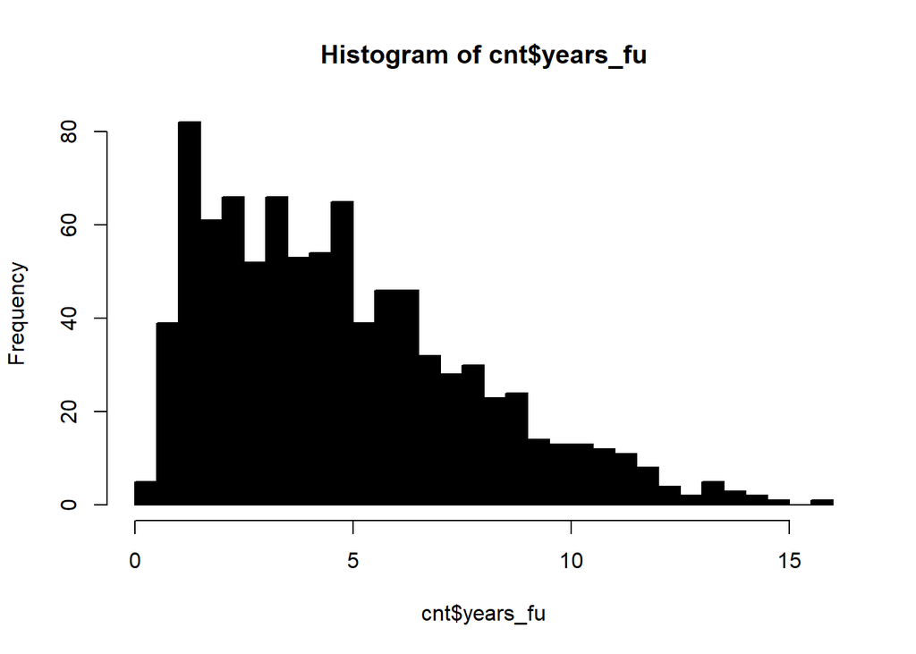

```r
hist(x = cnt$years_fu, col = "black", breaks = 30)
```

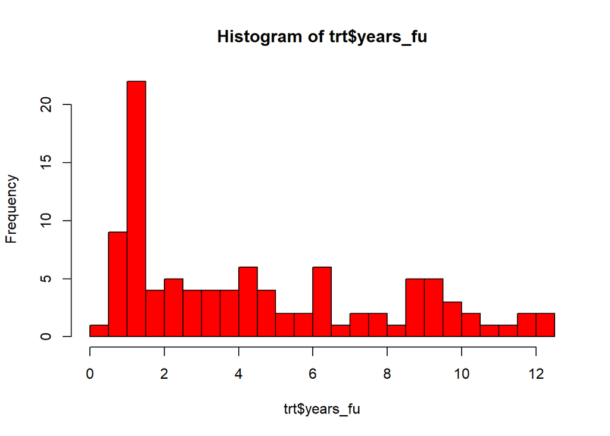

```r
hist(x = trt$years_fu, col = "red", breaks = 30)
```

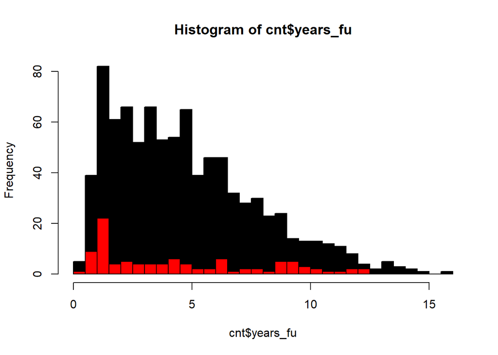

```r
hist(x = cnt$years_fu, col = "black", breaks = 30)
hist(x = trt$years_fu, col = "red", breaks = 30, add = TRUE)
```

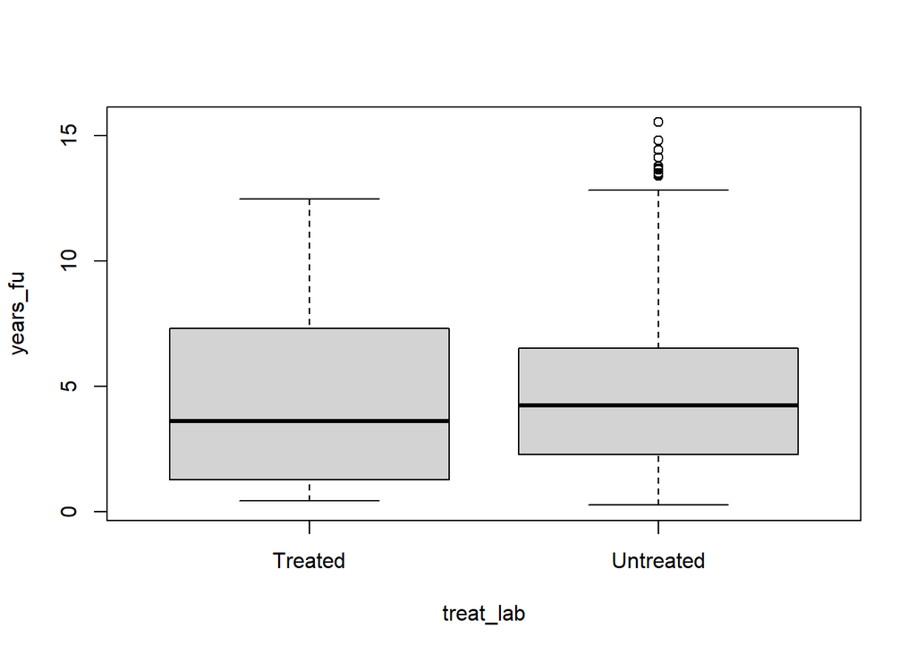

```r
boxplot(formula = years_fu ~ treat_lab, data = new)
```

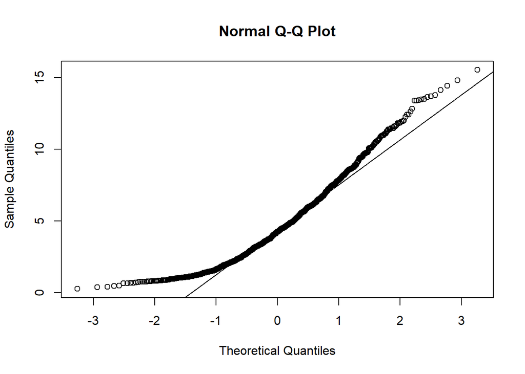

```r
qqnorm(y = cnt$years_fu, col = "black")
qqline(y = cnt$years_fu, col = "black")
```

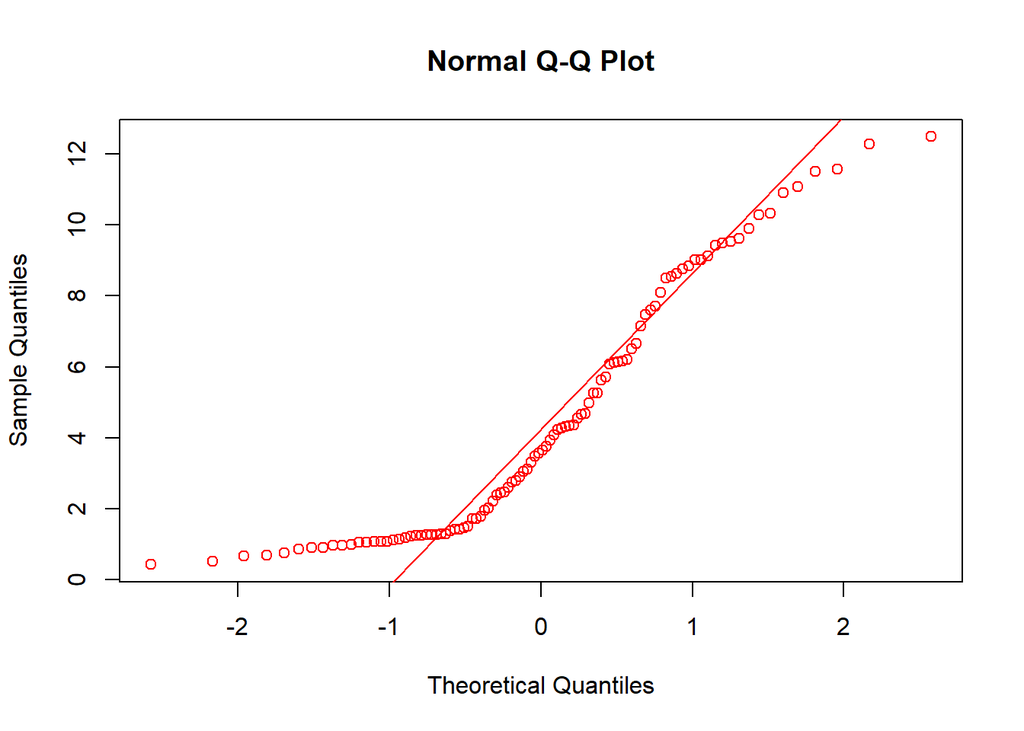

```r
qqnorm(y = trt$years_fu, col = "red")
qqline(y = trt$years_fu, col = "red")
```

```r
shapiro.test(x = cnt$years_fu)
```

```
    Shapiro-Wilk normality test

data:  cnt$years_fu
W = 0.93841, p-value < 2.2e-16
```

```r
shapiro.test(x = trt$years_fu)
```

```
    Shapiro-Wilk normality test

data:  trt$years_fu
W = 0.89076, p-value = 5.333e-07
```

### 4.3.5. Mann-WhitneyのU検定

```r
wilcox.test(formula = years_fu ~ treat_lab, data = new)
```

```
    Wilcoxon rank sum test with continuity correction

data:  years_fu by treat_lab
W = 40778, p-value = 0.1234
alternative hypothesis: true location shift is not equal to 0
```

## 4.4. 連続変数のアウトカムを3群間以上で比較する場合

### 4.4.2. 一元配置の分散分析

```r
oneway.test(formula = years_fu ~ ps_lab, data = new, var.equal = TRUE)
```

```
    One-way analysis of means

data:  years_fu and ps_lab
F = 1.6732, num df = 3, denom df = 943, p-value = 0.1711
```

### 4.4.3. Kruskal-Wallisの順位和検定

```r
kruskal.test(formula = years_fu ~ ps_lab, data = new)
```

```
    Kruskal-Wallis rank sum test

data:  years_fu by ps_lab
Kruskal-Wallis chi-squared = 6.1567, df = 3, p-value = 0.1042
```

## 4.5. アウトカムを連続変数によって説明する場合

### 4.5.2. Pearsonの積率相関係数

```r
cor.test(formula = ~ years_fu + depth_cm, data = new, method = "pearson")
```

```
    Pearson's product-moment correlation

data:  years_fu and depth_cm
t = -11.754, df = 975, p-value < 2.2e-16
alternative hypothesis: true correlation is not equal to 0
95 percent confidence interval:
 -0.4060366 -0.2961130
sample estimates:
       cor
-0.3522892
```

```r
cor.test(formula = ~ years_fu + age, data = new, method = "pearson")
```

```
    Pearson's product-moment correlation

data:  years_fu and age
t = -4.0895, df = 998, p-value = 4.671e-05
alternative hypothesis: true correlation is not equal to 0
95 percent confidence interval:
 -0.18886916 -0.06691872
sample estimates:
       cor
-0.1283792
```

### 4.5.3. Spearmanの順位相関係数

```r
cor.test(formula = ~ years_fu + depth_cm, data = new, method = "spearman")
```

```
    Spearman's rank correlation rho

data:  years_fu and depth_cm
S = 216720790, p-value < 2.2e-16
alternative hypothesis: true rho is not equal to 0
sample estimates:
       rho
-0.3943397
```

### 4.5.4. Kendallの順位相関係数

```r
cor.test(formula = ~ event_y1 + depth_cm, data = new, method = "kendall")
```

```
    Kendall's rank correlation tau

data:  event_y1 and depth_cm
z = 1.2362, p-value = 0.2164
alternative hypothesis: true tau is not equal to 0
sample estimates:
       tau
0.03333752
```

## 4.6. 離散変数のアウトカムデータを複数群間で比較する場合

### 4.6.1. カイ二乗検定

```r
frq <- table(new$treat_lab, new$event_lab)
prp <- prop.table(x = frq, margin = 1)
frq
```

```
             No Yes
  Treated    65  35
  Untreated 566 334
```

```r
prp
```

```
                   No       Yes
  Treated   0.6500000 0.3500000
  Untreated 0.6288889 0.3711111
```

```r
ct <- chisq.test(x = frq, correct = T)
ct
```

```
    Pearson's Chi-squared test with Yates' continuity correction

data:  frq
X-squared = 0.093531, df = 1, p-value = 0.7597
```

### 4.6.2. Fisherの正確検定

```r
ct$expected
```

```
               No   Yes
  Treated    63.1  36.9
  Untreated 567.9 332.1
```

```r
fisher.test(x = frq)
```

```
    Fisher's Exact Test for Count Data

data:  frq
p-value = 0.7435
alternative hypothesis: true odds ratio is not equal to 1
95 percent confidence interval:
 0.6986058 1.7426145
sample estimates:
odds ratio
  1.095831
```

## 4.7. 生存時間を評価する場合

### 4.7.3. Kaplan-Meier曲線の作図

```r
#install.packages("survival")
library(survival)
fit <- survfit(formula = Surv(time = years_fu, event = event_y1) ~ treat_lab, data = new)

#install.packages("survminer")
library(survminer)
```

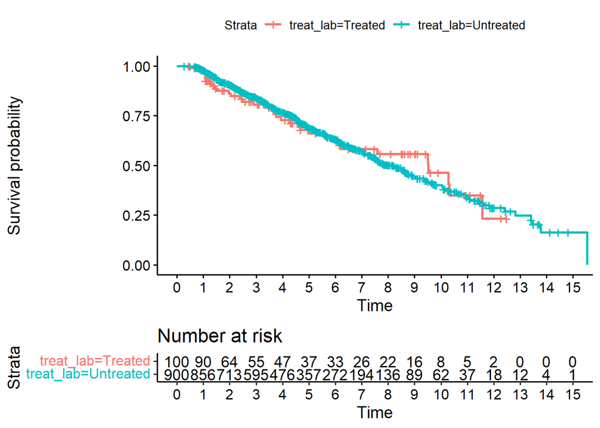

```r
ggsurvplot(fit = fit, data = new, risk.table = TRUE, break.x.by = 1)
```

### 4.7.4. Log-rank検定

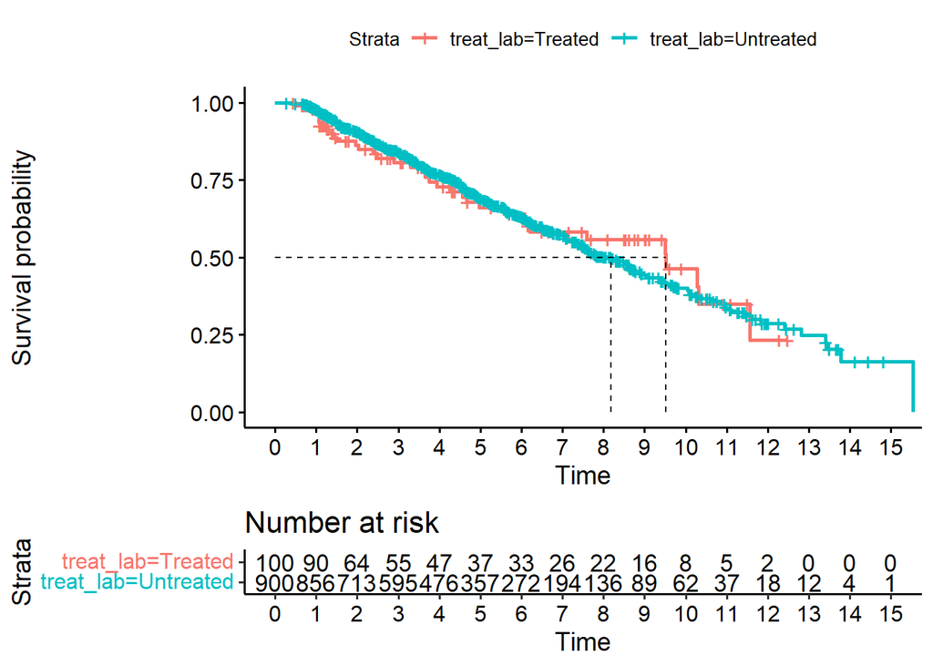

```r
ggsurvplot(fit = fit, data = new, risk.table = TRUE, break.time.by = 1, surv.median.line = "hv")    # 累積生存
```

```r
survdiff(formula = Surv(time = years_fu, event = event_y1) ~ treat_lab, data = new)
```

```
Call:
survdiff(formula = Surv(time = years_fu, event = event_y1) ~
    treat_lab, data = new)

                      N Observed Expected (O-E)^2/E (O-E)^2/V
treat_lab=Treated   100       35     35.3  0.002598   0.00289
treat_lab=Untreated 900      334    333.7  0.000275   0.00289

 Chisq= 0  on 1 degrees of freedom, p= 1
```

# 第5章 回帰モデル

CSVファイルの読みこみ

```r
new <- read.csv("new.csv")
```

## 連続変数の回帰モデル

## 5.2. 線形回帰モデル

### 5.2.1. 線形回帰モデルの基本

```r
library(rms)
fit <-  ols(formula = years_fu ~ depth_cm, data = new)
fit
```

```
Frequencies of Missing Values Due to Each Variable
years_fu depth_cm
       0       23

Linear Regression Model

ols(formula = years_fu ~ depth_cm, data = new)

                Model Likelihood    Discrimination
                      Ratio Test           Indexes
Obs     977    LR chi2    129.46    R2       0.124
sigma2.8443    d.f.            1    R2 adj   0.123
d.f.    975    Pr(> chi2) 0.0000    g        1.168

Residuals

    Min      1Q  Median      3Q     Max
-4.6949 -2.1667 -0.6076  1.5538  9.5724

          Coef    S.E.   t      Pr(>|t|)
Intercept  8.0476 0.2910  27.65 <0.0001
depth_cm  -2.2738 0.1935 -11.75 <0.0001
```

```r
dd <- datadist(x = new)
options(datadist = "dd")
summary(object = fit)
```

```
             Effects              Response : years_fu

 Factor   Low High Diff. Effect  S.E.    Lower 0.95 Upper 0.95
 depth_cm 1.1 1.7  0.6   -1.3643 0.11607 -1.592     -1.1365
```

```r
summary(object = fit, depth_cm = c(0,1))
```

```
             Effects              Response : years_fu

 Factor   Low High Diff. Effect  S.E.    Lower 0.95 Upper 0.95
 depth_cm 0   1    1     -2.2738 0.19345 -2.6534    -1.8942
```

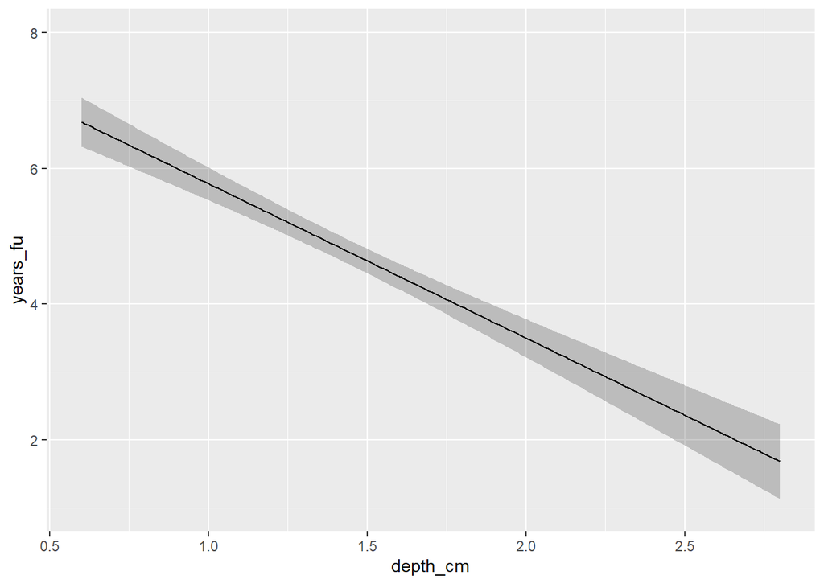

```r
pred <- Predict(object = fit, depth_cm)
ggplot(data = pred)
```

### 5.2.2. 線形回帰モデルの仮定の評価

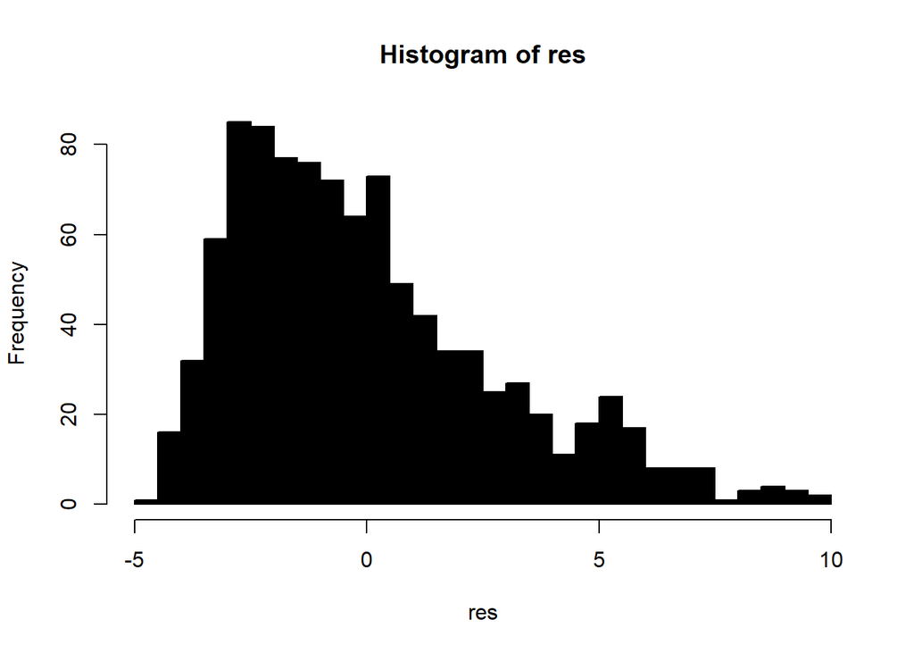

```r
# 正規性
res <- fit$residuals
hist(x = res, col = "black", breaks = 30)
```

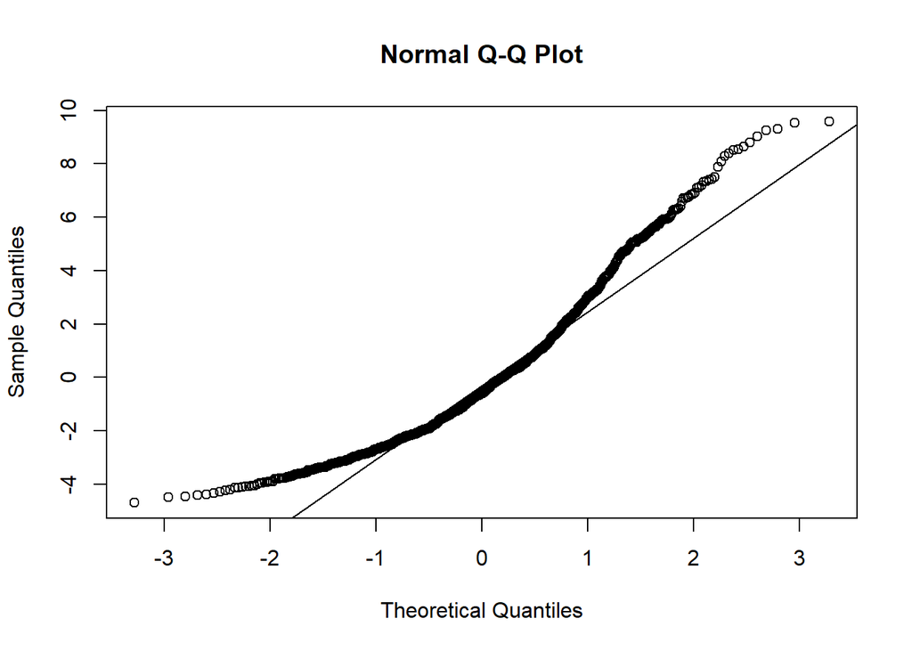

```r
qqnorm(y = res, col = "black")
qqline(y = res, col = "black")
```

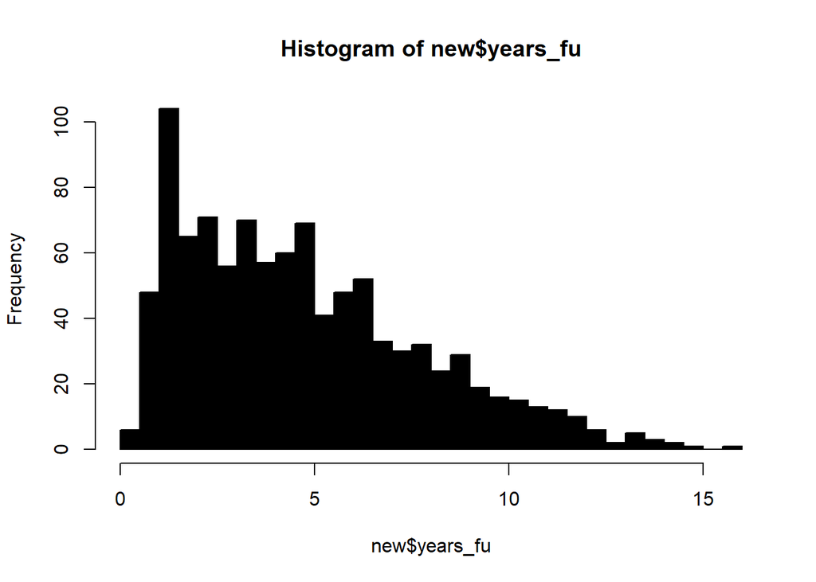

```r
new$ln_years_fu <- log(new$years_fu)
hist(x = new$years_fu, col = "black", breaks = 30)
```

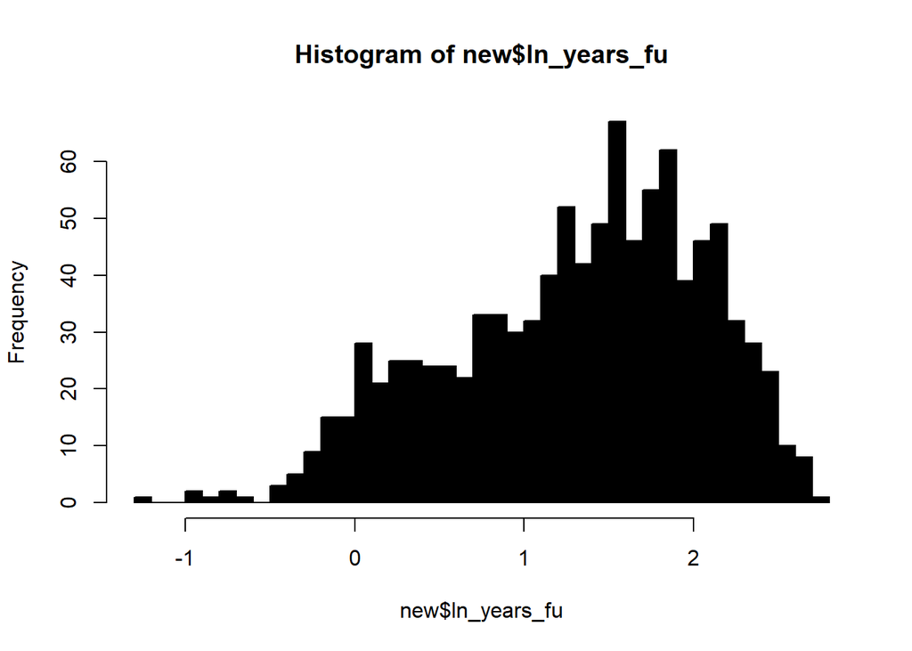

```r
hist(x = new$ln_years_fu, col = "black", breaks = 30)
```

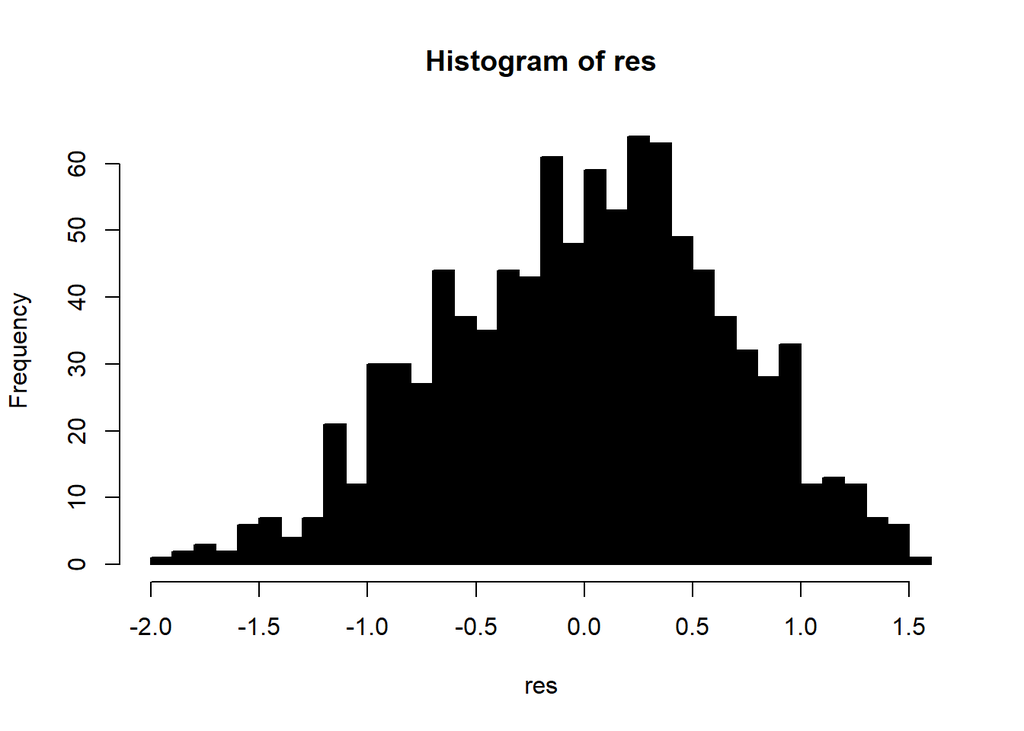

```r
fit <- ols(formula = ln_years_fu ~ depth_cm, data = new)
# fit <- ols(formula = log(years_fu) ~ depth_cm, data = new)
res <- fit$residuals
hist(x = res, col = "black", breaks = 30)
```

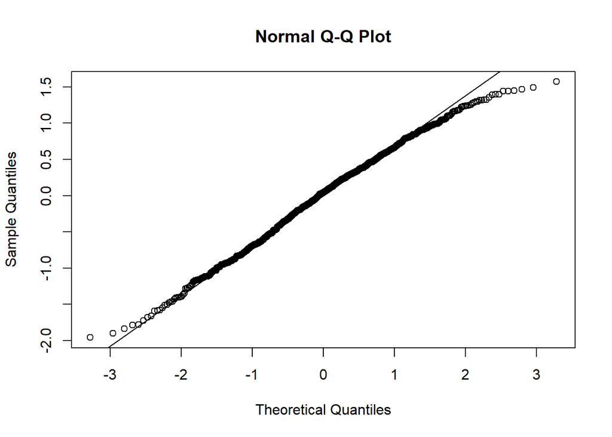

```r
qqnorm(y = res, col = "black")
qqline(y = res, col = "black")
```

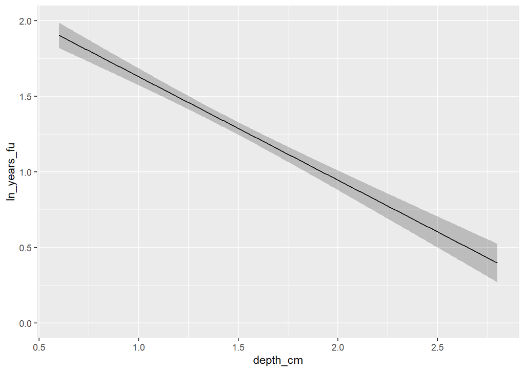

```r
pred <- Predict(object = fit, depth_cm)
ggplot(data = pred)
```

```r
smr <- summary(object = fit, depth_cm = c(1,2))
smr
```

```
             Effects              Response : ln_years_fu

 Factor   Low High Diff. Effect  S.E.     Lower 0.95 Upper 0.95
 depth_cm 1   2    1     -0.6846 0.044707 -0.77233   -0.59687
```

```r
coef <- smr[, c("Effect","Lower 0.95","Upper 0.95")]
coef
```

```
    Effect Lower 0.95 Upper 0.95
-0.6845980 -0.7723307 -0.5968654
```

```r
exp(coef)
```

```
    Effect Lower 0.95 Upper 0.95
 0.5042929  0.4619352  0.5505347
```

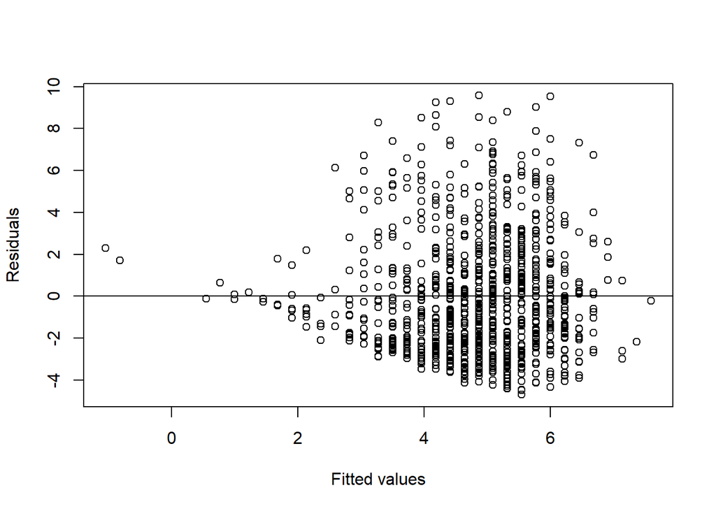

```r
# 等分散性
fit <- ols(formula = years_fu ~ depth_cm, data = new)
pred <- fit$fitted.values
res <- fit$residuals
plot(x = pred, y = res, xlab = "Fitted values", ylab = "Residuals")
abline(h = 0)
```

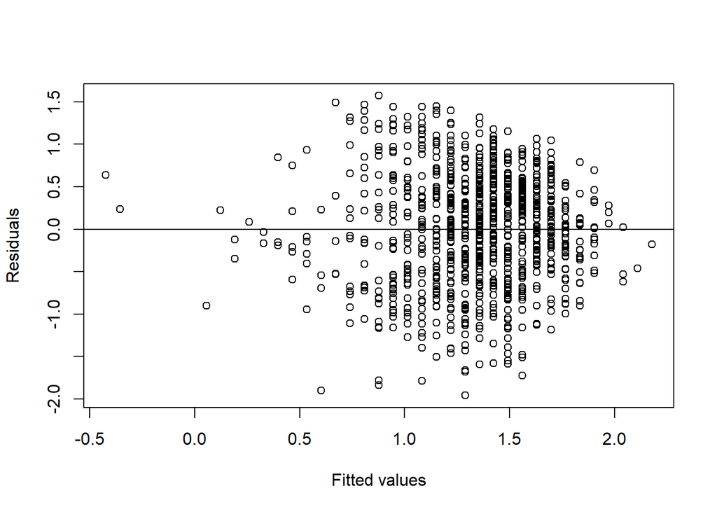

```r
fit <- ols(formula = ln_years_fu ~ depth_cm, data = new)
pred <- fit$fitted.values
res <- fit$residuals
plot(x = pred, y = res, xlab = "Fitted values", ylab = "Residuals")
abline(h = 0)
```

### 5.2.3. 説明変数が2値変数の場合

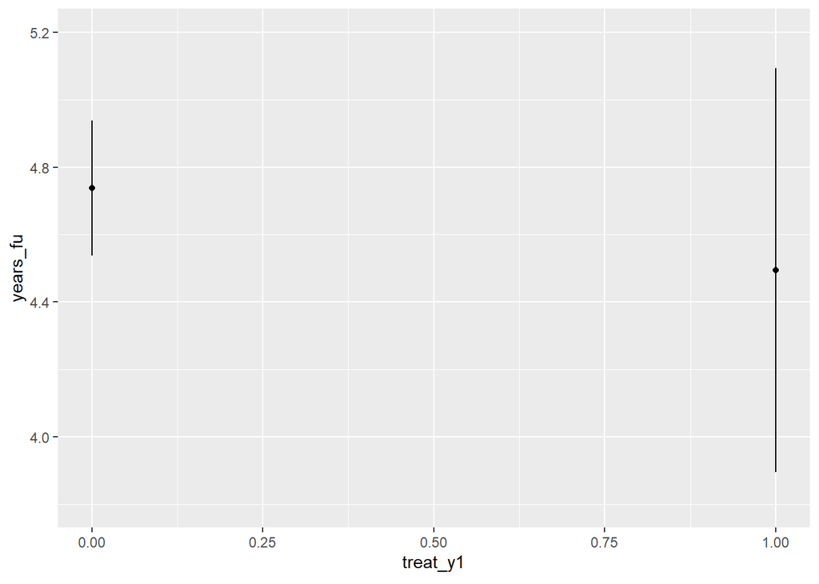

```r
# 数値型
fit <- ols(formula = years_fu ~ treat_y1, data = new)
pred <- Predict(object = fit, treat_y1)
ggplot(data = pred)
```

```r
summary(object = fit)
```

```
             Effects              Response : years_fu

 Factor   Low High Diff. Effect   S.E.    Lower 0.95 Upper 0.95
 treat_y1 0   1    1     -0.24402 0.32196 -0.87581   0.38778
```

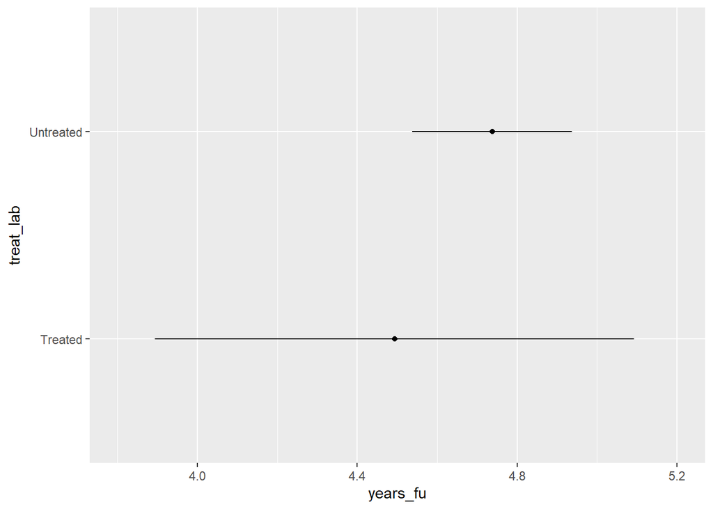

```r
# 文字列型
fit <- ols(formula = years_fu ~ treat_lab, data = new)
pred <- Predict(object = fit, treat_lab)
ggplot(data = pred)
```

```r
summary(object = fit)
```

```
             Effects              Response : years_fu

 Factor                        Low High Diff. Effect   S.E.    Lower 0.95
 treat_lab - Treated:Untreated 2   1    NA    -0.24402 0.32196 -0.87581
 Upper 0.95
 0.38778
```

### 5.2.4. 説明変数が3値以上の離散変数の場合

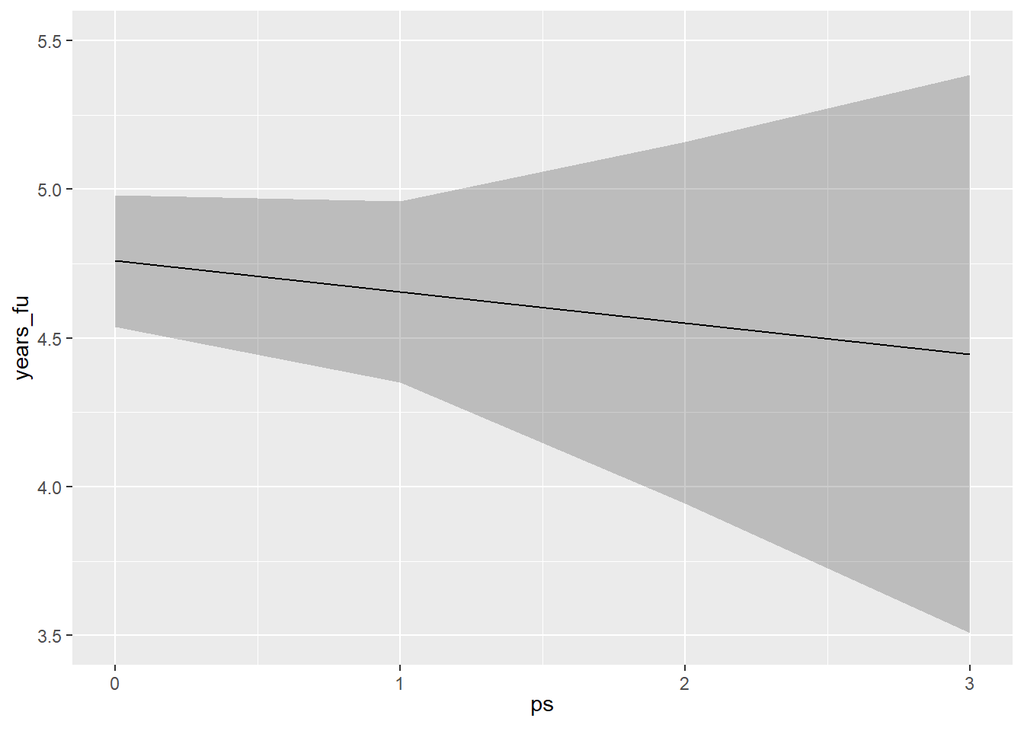

```r
# 数値型
fit <- ols(formula = years_fu ~ ps, data = new)
pred <- Predict(object = fit, ps)
ggplot(data = pred)
```

```r
summary(object = fit)
```

```
             Effects              Response : years_fu

 Factor Low High Diff. Effect   S.E.    Lower 0.95 Upper 0.95
 ps     0   1    1     -0.10444 0.17378 -0.44548   0.2366
```

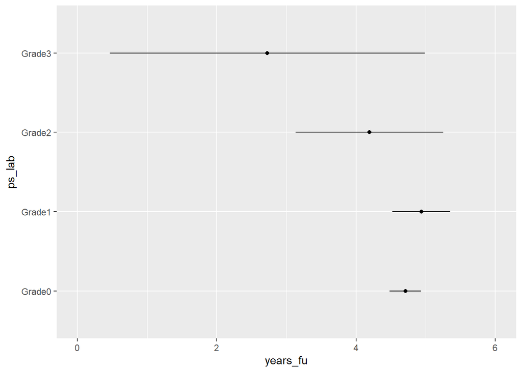

```r
# 文字列型
fit <- ols(formula = years_fu ~ ps_lab, data = new)
pred <- Predict(object = fit, ps_lab)
ggplot(data = pred)
```

```r
summary(object = fit)
```

```
             Effects              Response : years_fu

 Factor                 Low High Diff. Effect   S.E.    Lower 0.95 Upper 0.95
 ps_lab - Grade1:Grade0 1   2    NA     0.22887 0.24039 -0.24288   0.70063
 ps_lab - Grade2:Grade0 1   3    NA    -0.51592 0.55122 -1.59770   0.56584
 ps_lab - Grade3:Grade0 1   4    NA    -1.98300 1.15820 -4.25600   0.29000
```

```r
summary(object = fit, ps_lab = "Grade3")
```

```
             Effects              Response : years_fu

 Factor                 Low High Diff. Effect S.E.   Lower 0.95 Upper 0.95
 ps_lab - Grade0:Grade3 4   1    NA    1.9830 1.1582 -0.290000  4.2560
 ps_lab - Grade1:Grade3 4   2    NA    2.2119 1.1716 -0.087401  4.5111
 ps_lab - Grade2:Grade3 4   3    NA    1.4671 1.2723 -1.029800  3.9639
```

```r
contrast(fit = fit,
         a = list(ps_lab = c("Grade1","Grade2","Grade3")),
         b = list(ps_lab = c("Grade0")))
```

```
     Contrast      S.E.      Lower     Upper     t Pr(>|t|)
11  0.2288713 0.2403863 -0.2428828 0.7006253  0.95   0.3413
22 -0.5159216 0.5512184 -1.5976783 0.5658351 -0.94   0.3495
33 -1.9829940 1.1582261 -4.2559929 0.2900048 -1.71   0.0872

Error d.f.= 943

Confidence intervals are 0.95 individual intervals
```

```r
anova(object = fit)
```

```
                Analysis of Variance          Response: years_fu

 Factor     d.f. Partial SS MS        F    P
 ps_lab       3    46.670   15.556666 1.67 0.1711
 REGRESSION   3    46.670   15.556666 1.67 0.1711
 ERROR      943  8767.361    9.297308
```

## 5.3. 目的変数が２値変数の場合

### 5.3.1. ロジスティック回帰モデルによるオッズ比の推定

```r
fit <- lrm(formula = event_y1 ~ treat_lab, data = new)
summary(object = fit)
```

```
             Effects              Response : event_y1

 Factor                        Low High Diff. Effect    S.E.    Lower 0.95
 treat_lab - Treated:Untreated 2   1    NA    -0.091586 0.22072 -0.52419
  Odds Ratio                   2   1    NA     0.912480      NA  0.59204
 Upper 0.95
 0.34102
 1.40640
```

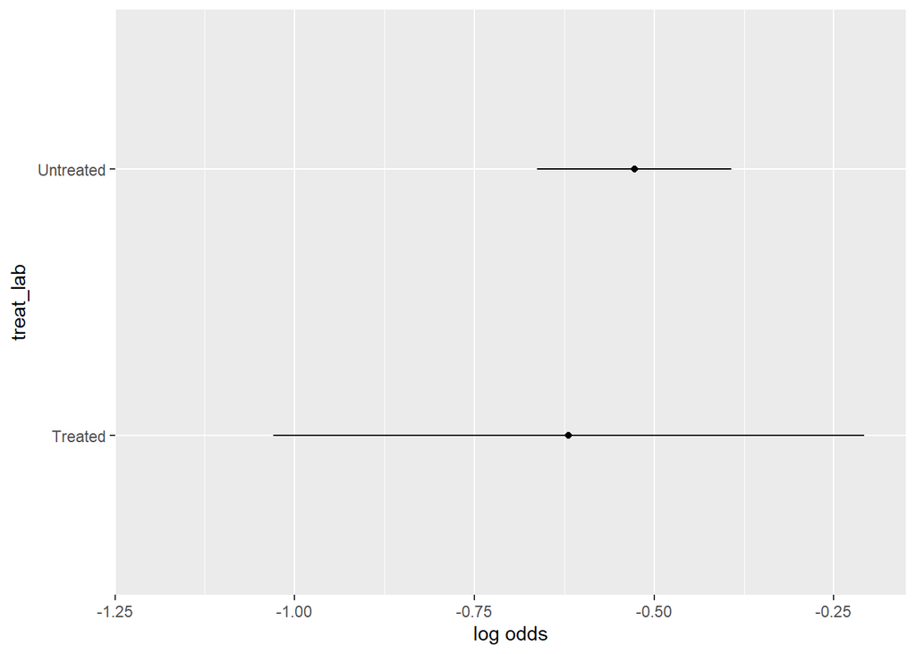

```r
pred <- Predict(object = fit, treat_lab)
ggplot(data = pred)
```

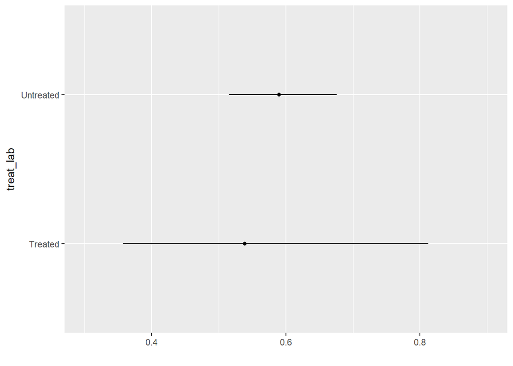

```r
pred <- Predict(object = fit, treat_lab, fun = exp)
ggplot(data = pred)
```

### 5.3.2. 修正ポアソン回帰モデルによるリスク比の推定

```r
fit <- Glm(formula = event_y1 ~ treat_lab, data = new, family = poisson(link = "log"), x = T)
rfit <- robcov(fit = fit, cluster = new$id)
summary(object = rfit)
```

```
             Effects              Response : event_y1

 Factor                        Low High Diff. Effect    S.E.    Lower 0.95
 treat_lab - Treated:Untreated 2   1    NA    -0.058568 0.14302 -0.33922
 Upper 0.95
 0.22208
```

```r
smr <- summary(object = rfit)
coef <- smr[, c("Effect","Lower 0.95","Upper 0.95")]
exp(coef)
```

```
    Effect Lower 0.95 Upper 0.95
 0.9431138  0.7123257  1.2486755
```

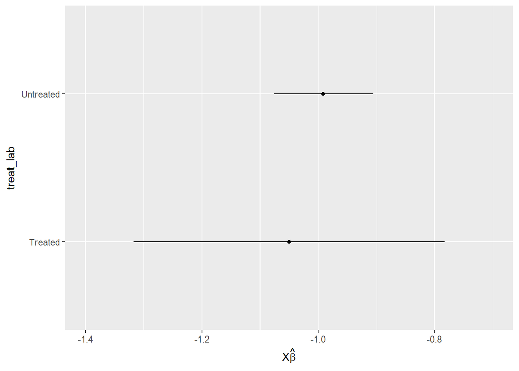

```r
pred = Predict(object = rfit, treat_lab)
ggplot(data = pred)
```

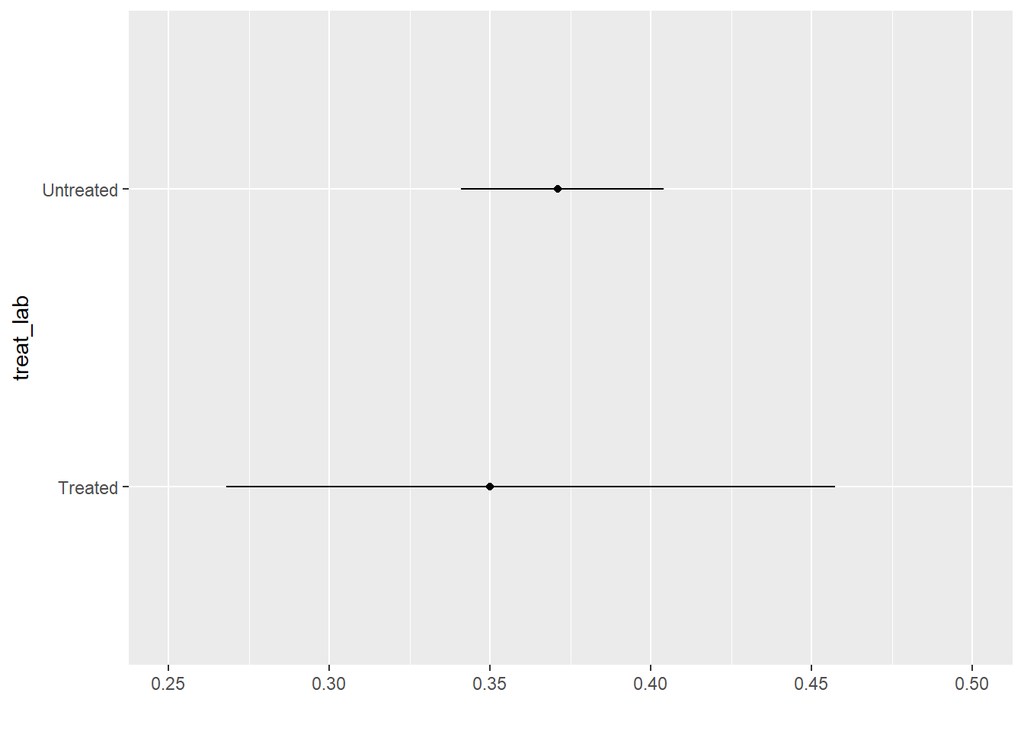

```r
pred = Predict(object = rfit, treat_lab, fun = exp)
ggplot(data = pred)
```

### 5.3.3. 修正ポアソン回帰モデルによるリスク差の推定

```r
fit <- Glm(formula = event_y1 ~ treat_lab, data = new, family = poisson(link = "identity"), x = T)
rfit <- robcov(fit = fit, cluster = new$id)
summary(object = rfit)
```

```
             Effects              Response : event_y1

 Factor                        Low High Diff. Effect    S.E.     Lower 0.95
 treat_lab - Treated:Untreated 2   1    NA    -0.021111 0.050342 -0.1199
 Upper 0.95
 0.077677
```

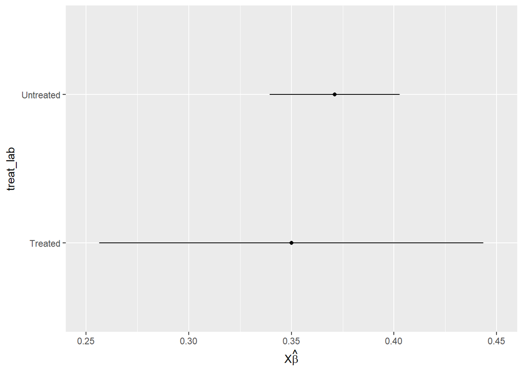

```r
pred = Predict(object = rfit, treat_lab)
ggplot(data = pred)
```

## 5.4. 目的変数がイベント発生までの時間の場合

### 5.4.1. Cox比例ハザード回帰モデル

```r
fit <- cph(formula = Surv(time = years_fu, event = event_y1) ~ treat_lab, data = new)
summary(fit, treat_lab)
```

```
             Effects              Response : Surv(time = years_fu, event = event_y1)

 Factor                        Low High Diff. Effect   S.E.   Lower 0.95
 treat_lab - Treated:Untreated 2   1    NA    -0.00947 0.1781 -0.35854
  Hazard Ratio                 2   1    NA     0.99057     NA  0.69869
 Upper 0.95
 0.3396
 1.4044
```

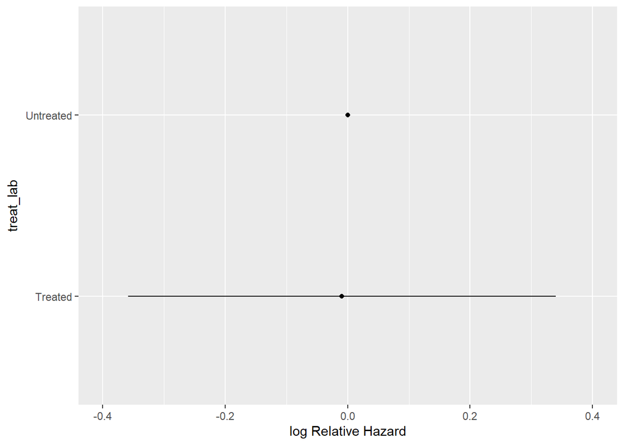

```r
pred = Predict(object = fit, treat_lab, ref.zero = TRUE)
ggplot(data = pred)
```

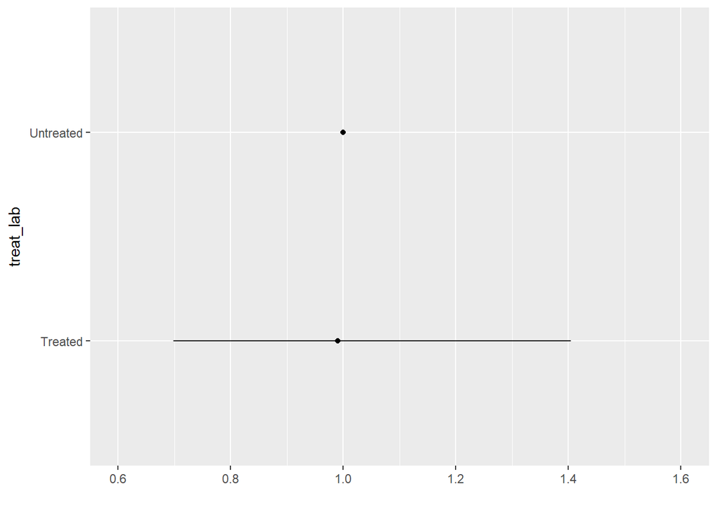

```r
pred = Predict(object = fit, treat_lab, ref.zero = TRUE, fun = exp)
ggplot(data = pred)
```

### 5.4.2. 比例ハザード性の評価

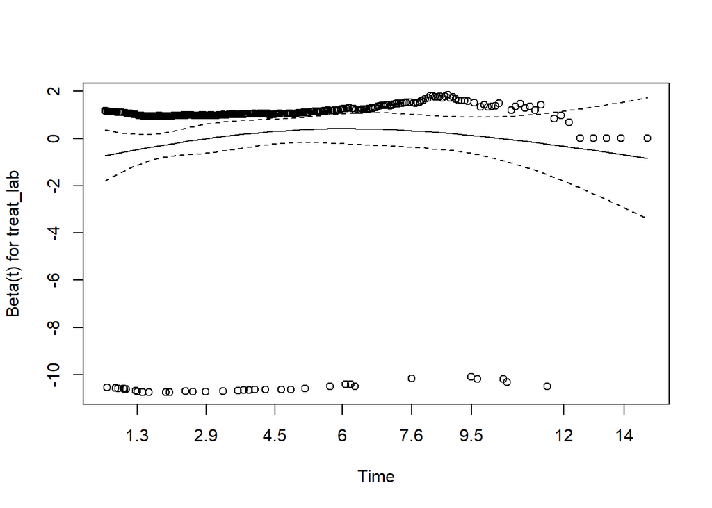

```r
library(survival)
zph <- cox.zph(fit = fit)
plot(x = zph)
```

```r
zph
```

```
          chisq df    p
treat_lab  1.24  1 0.27
GLOBAL     1.24  1 0.27
```